# Using colourvision

Felipe M. Gawryszewski

2021-07-31

#Introduction This is a practical user guide to `colourvision`. Colour vision models allow appraisals of colour patches independently of the human vision. More detailed explanation on colour vision models is provided elsewhere (Kelber, Vorobyev, and Osorio 2003; Endler and Mielke 2005; Osorio and Vorobyev 2008; Kemp et al. 2015; Renoult, Kelber, and Schaefer 2017; Gawryszewski 2018).

Package `colourvision` has functions to the three most commonly used models by ecologists, behavioural ecologists, and evolutionary biologists (Chittka 1992; Vorobyev and Osorio 1998; Vorobyev et al. 1998; Endler and Mielke 2005), and a generic function to build alternative models based on the same set of general assumptions. These models have been extended to accept any number of photoreceptor types, i.e., the same model may be applied to a dichromatic mammal and a tentatively pentachromatic dipterean. Modelling functions provide a comprehensive output, which may be visualised into publication-ready colour space plots.

#Data handling This section shows functions applied to colour data before model calculations.

##`spec.denoise()`

Applies a `smooth.spline` for a data frame containing spectrometric data. Useful when raw data from spectrophotometer output are noisy.

```r
spider.smooth<-spec.denoise(spider)
```

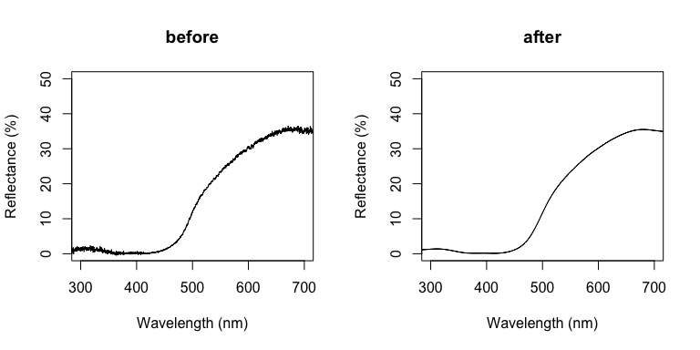

Figure 1. Effect of `spec.denoise( )` applied to a reflectance curve.

##`photor()` Photoreceptor sensitivity curves are seldom available, but they can be estimated using the wavelength of maximum sensitivity ($\lambda_{max}$; Govardovskii et al. 2000). `photor` generates photoreceptor sensitivity spectra based on $\lambda_{max}$ values:

```r
human<-photor(lambda.max = c(420,530,560), lambda = seq(400, 700, 1))
```

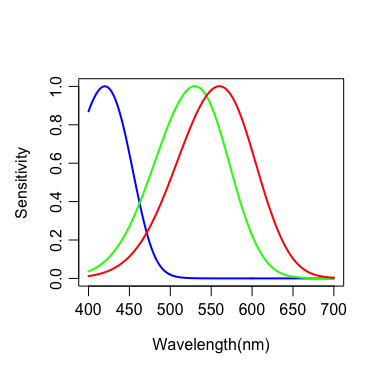

Figure 2. Estimated photoreceptor sensitivity curves based on the wavelength of maximum sensitivity using `photor( )` function.

##`logistic()`

Creates a sigmoid reflectance curve. Useful for simulations using colour vision models (see for instance Gawryszewski 2018).

```r
R<-logistic(x0=500, L=80, k=0.04)
```

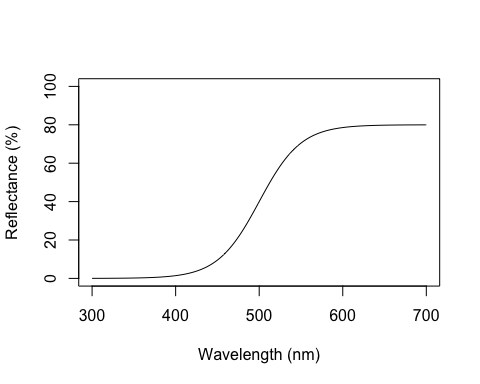

Figure 3. Simulated reflectance spectrum using the `logistic( )` function.

##`energytoflux()`

Photoreceptors respond to photon numbers, not photon energy (Endler 1990). `energytoflux` converts Irradiance datum from energy units ($uW \times cm^{-2} \times nm^{-1}$) to quantum flux units ($umol \times m^{-2} \times s^{-1}$).

```r
D65photon<-energytoflux(D65energy)
```

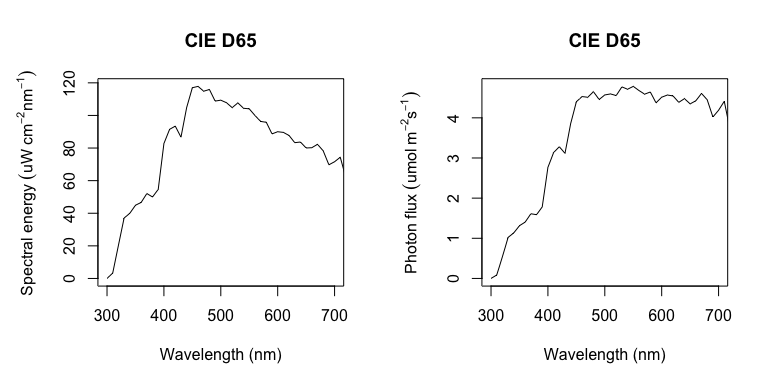

Figure 4. CIE D65 in photon energy (left) and quantum flux units (right)

#Colour Vision Models ##The Basics This section serves as a brief introduction to colour vision models, and to introduce internal package functions used to calculate colour vision models. For model specific functions (`CTTKmodel`, `EMmodel`, `RNLmodel`, `RNLthres`, and `GENmodel`), please refer to further sections in this manual.

Colour vision models require a minimum of four parameters for calculations: (1) photoreceptor sensitivity curves, (2) background reflectance spectrum, (3) illuminant spectrum, and (4) the stimulus reflectance spectrum (stimulus). Receptor noise limited models also require photoreceptor noise for each photoreceptor type.

Firstly, one needs to estimate photon catches of each photoreceptor type in the retina, which is a function of the stimulus reflectance, photoreceptor sensitivity, and the illuminant spectrum:

$$Q_i = \int_{300}^{700} R(\lambda)I(\lambda)C_i(\lambda) d\lambda$$
where $R(\lambda)$ denote the stimulus reflectance, $I(\lambda)$ the illuminant spectrum, and $C(\lambda)$ the photoreceptor sensitivity curves. Note that the illuminant spectrum has to be in quantum flux units, not energy units, because photoreceptors respond to photon numbers, not photon energy.

In `colourvision` quantum catches are represented by function `Q`. Here, quantum catches of a given stimulus (`R`) are estimated by each photoreceptor type found in *Apis mellifera* (`bee`; Peitsch et al. 1992) under the CIE D65 standard illuminant (`D65`):

```r
R<-logistic(x=seq(300,700,1), x0=500, L=80, k=0.04)
data("bee")
data("D65")

Qcatch1<-Q(R=R,I=D65,C=bee[c(1,2)],interpolate=TRUE,nm=seq(300,700,1))
Qcatch2<-Q(R=R,I=D65,C=bee[c(1,3)],interpolate=TRUE,nm=seq(300,700,1))
Qcatch3<-Q(R=R,I=D65,C=bee[c(1,4)],interpolate=TRUE,nm=seq(300,700,1))
```

In general, colour vision models assume that photoreceptors are adapted to the background. This is achieved by calculating quantum catch of each photoreceptor type in relation to the quantum catches based on the background reflectance (also known as the von Kries transformation).
$$Qb_i = \int_{300}^{700} Rb(\lambda)I(\lambda)C_i(\lambda) d\lambda$$
$$q_i = \frac{Q_i}{Qb_i}$$

where $Rb$ is the background reflectance, $Q_i$ is the quantum catch from the stimulus reflectance, and $Qb_i$ is the quantum catch from the background reflectance.

Relative quantum catches are calculated using function `Qr`. Here photoreceptors are assumed to be adapted to a reflectance background based on samples collected in the Brazilian savanna (Gawryszewski and Motta 2012):

```r
data("Rb")

Qr1<-Qr(R=R,Rb=Rb, I=D65,C=bee[c(1,2)],interpolate=TRUE,nm=seq(300,700,1))
Qr2<-Qr(R=R,Rb=Rb, I=D65,C=bee[c(1,3)],interpolate=TRUE,nm=seq(300,700,1))
Qr3<-Qr(R=R,Rb=Rb, I=D65,C=bee[c(1,4)],interpolate=TRUE,nm=seq(300,700,1))
```

The relationship between photoreceptor input and output are assumed to be non-linear. Each colour vision model uses a different transformation function (e.g., `log`, `x/(x+1)`), but with the same general result:

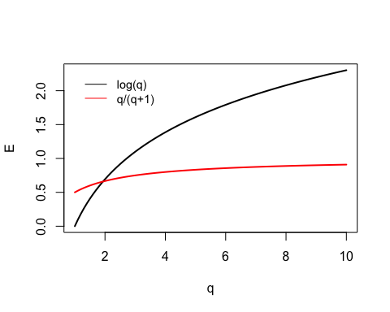

Figure 5. Relationship between photoreceptor input and output typically used in colour vision models.

For instance, Chittka (1992) assumes an asymptotic curve with limit = 1:
$$E_i = \frac{q_i}{q_i+1}$$

Photoreceptor outputs are then projected as equidistant vectors into a colour space. Again, each model will present differently arranged vectors, however, this arrangement is arbitrary and has no effect on model predictions. The length of the resultant vector represents the chromaticity distance of the stimulus in relation to the background, and vector coordinates represent the stimulus locus in the animal colour space (colour locus).

For instance, `colour_space` generates a general colour space based on any number of photoreceptor types, and calculates colour locus coordinates for a given photoreceptor output:

```r
colour_space(n=3, type="length", length=1, edge=NA, q=c(Qr1,Qr2,Qr3))
```

```
## $coordinates
##       X1       X2
## 1.458867 4.329547
##
## $vector_matrix
##            v1         v2 v3
## X1 -0.8660254  0.8660254  0
## X2 -0.5000000 -0.5000000  1
```

##Chittka (1992) Colour Hexagon Chittka (1992) developed a colour vision model based on trichromatic hymenopteran vision. This model has later been extended to tetrachromatic avian vision (Thery and Casas 2002). In `colourvision` this model has been further extended to accept any number of photoreceptor types ($n\geq2$).

Photoreceptor outputs ($E_i$) are calculated by:
$${E_i = \frac{q_i}{q_i+1}}$$

Then, for trichromatic vision, coordinates in the colour space are found by (Chittka 1992):
$${X_1 = \frac{\sqrt{3}}{2}(E_3-E_1)}$$
$${X_2 = E_2-\frac{1}{2}(E_1+E_3)}$$
For tetrachromatic vision (Thery and Casas 2002):
$${X_1 = \frac{\sqrt{3}\sqrt{2}}{3}(E_3-E_4)}$$
$${X_2 = E_1-\frac{1}{3}(E_2+E_3+E_4)}$$
$${X_3 = \frac{2\sqrt{2}}{3}(\frac{1}{2}(E_3+E_4)-E_2)}$$
Then, for a pentachromatic animal (Gawryszewski 2018):
$${X_1 = \frac{5}{2\sqrt{2}\sqrt{5}}(E_2-E_1)}$$
$${X_2 = \frac{5\sqrt{2}}{2\sqrt{3}\sqrt{5}}(E_3-\frac{E_1+E_2}{2})}$$
$${X_3 = \frac{5\sqrt{3}}{4\sqrt{5}}(E_4-\frac{E_1+E_2+E_3}{3})}$$
$${X_4 = E_5-\frac{E1+E2+E3+E4}{4}}$$

###`CTTKmodel()` Chittka (1992) model is represented by function `CTTKmodel`. This functions needs (1) photoreceptor sensitivities curves, (2) background reflectance spectrum, (3) illuminant spectrum, and (4) stimulus reflectance spectra:

A worked example:

1. Load data files: *Apis mellifera* photoreceptor sensitivity curves (Peitsch et al. 1992), Background reflectance and the illuminant spectrum:

```r
data("bee")
data("Rb")
data("D65")
```

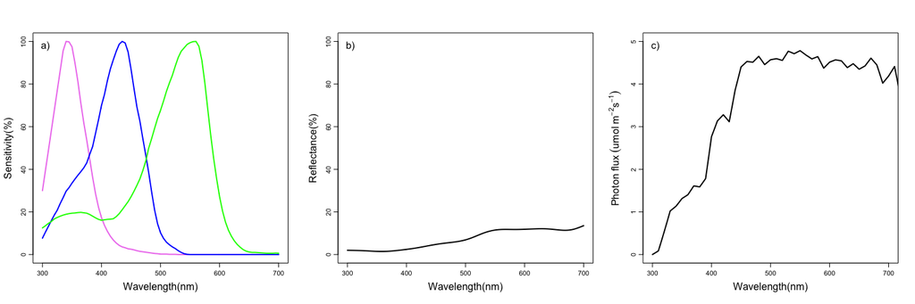

Figure 6. *Apis mellifera* photoreceptor sensitivity curves (a; data from Peitsch et al. 1992), background reflectance spectrum (b; data from Gawryszewski and Motta 2012), and CIE D65 standard illuminant (c).

2. Create simulated reflectance data:

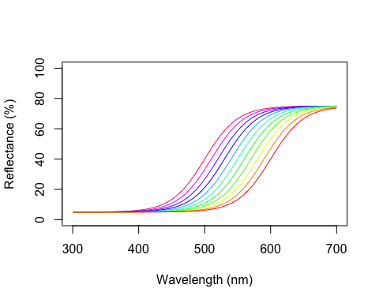

Figure 7. Simulated reflectance spectra.

```r
midpoint<-seq(from = 500, to = 600, 10)
W<-seq(300, 700, 1)
R<-data.frame(W)
for (i in 1:length(midpoint)) {
  R[,i+1]<-logistic(x = seq(300, 700, 1), x0=midpoint[[i]], L = 70, k=0.04)[,2]+5
}
names(R)[2:ncol(R)]<-midpoint
```

3. Run Chittka (1992) model:

```r
CTTKmodel3<-CTTKmodel(R=R, I=D65, C=bee, Rb=Rb)
```

Model output provides the relative quantum catches (Qr), photoreceptor outputs (E), colour locus coordinates (X), and the chromaticity distance of stimulus in relation to the background (deltaS).

`CTTKmodel3`

Table 1. `CTTKmodel()` output of a trichromatic animal, showing the relative quantum catches (Qr), photoreceptor outputs (E), colour locus coordinates (X), and the chromaticity distance of stimulus in relation to the background (deltaS)

|  | Qr1 | Qr2 | Qr3 | E1 | E2 | E3 | X1 | X2 | deltaS |
| --- | --- | --- | --- | --- | --- | --- | --- | --- | --- |
| 500 | 3.109465 | 3.304717 | 5.684952 | 0.7566593 | 0.7676967 | 0.8504103 | 0.0811907 | -0.0358381 | 0.0887485 |
| 510 | 2.936685 | 2.759015 | 5.269557 | 0.7459792 | 0.7339729 | 0.8404991 | 0.0818566 | -0.0592663 | 0.1010594 |
| 520 | 2.809985 | 2.336604 | 4.825336 | 0.7375318 | 0.7002941 | 0.8283361 | 0.0786388 | -0.0826398 | 0.1140763 |
| 530 | 2.718425 | 2.018160 | 4.360565 | 0.7310689 | 0.6686723 | 0.8134525 | 0.0713462 | -0.1035884 | 0.1257809 |
| 540 | 2.653176 | 1.783585 | 3.885885 | 0.7262656 | 0.6407511 | 0.7953288 | 0.0598105 | -0.1200461 | 0.1341207 |
| 550 | 2.607271 | 1.614217 | 3.413825 | 0.7227822 | 0.6174763 | 0.7734391 | 0.0438702 | -0.1306343 | 0.1378039 |

##Endler & Mielke (2005) The original model is available for tetrachromatic animals only. In `colourvision`, the model was extended to any number of photoreceptors (Gawryszewski 2018; see also Pike 2012).

First, relative quantum catches are log-transformed:

$$f_i = \ln(q_i)$$

where $q_i$ is the relative quantum catch of each photoreceptor type. The model uses only relative values, so that photoreceptor outputs ($E$) are given by:

$$E_i = \frac{f_i}{f_1+f_2+f_3+...+f_n}$$

Then, for tetrachromatic vision colour locus coordinates are found by (Endler and Mielke 2005):

$$X_1 = \sqrt{\frac{3}{2}}(1-2\frac{E2-E3-E1}{2})$$
$${X_2 = \frac{-1+3E_3+E_1}{2\sqrt{2}}}$$
$${X_3 = E_1-\frac{1}{4}}$$

Tetrachromatic chromaticity diagram (tetrahedron) in Endler and Mielke (2005) has a maximum photoreceptor vector of length = 0.75, which gives a tetrahedron with edge length = $\sqrt{\frac{3}{2}}$. The chromaticity coordinates for other colour spaces may preserve either the same vector length or the same edge length.

For instance, for dichromatic vision, coordinate (X1) in the colour space preserving the same vector length is found by:

$${X_1 = \frac{3}{4}(E_2-E_1)}$$

whereas if the edge length is preserved, $X_1$ is found by:

$$\frac{1}{2}\sqrt{\frac{3}{2}}(E_2-E_1)$$

###`EMmodel()`

Using the same data as in `CTTKmodel()` example:

```r
EMmodel3<-EMmodel(type="length",R=R,I=D65,Rb=Rb,C=bee)
```

Model output provides the relative quantum catches (Qr), photoreceptor outputs (E), colour locus coordinates (X), and the chromaticity distance of stimulus in relation to the background (deltaS).

Table 2. `EMmodel()` output of a trichromatic animal, showing the relative quantum catches (Qr), photoreceptor outputs (E), colour locus coordinates (X), and the chromaticity distance of stimulus in relation to the background (deltaS)

|  | Qr1 | Qr2 | Qr3 | E1 | E2 | E3 | X1 | X2 | deltaS |
| --- | --- | --- | --- | --- | --- | --- | --- | --- | --- |
| 500 | 3.109465 | 3.304717 | 5.684952 | 0.2788976 | 0.2938695 | 0.4272328 | 0.0097246 | 0.1056369 | 0.1060836 |
| 510 | 2.936685 | 2.759015 | 5.269557 | 0.2869612 | 0.2703373 | 0.4427015 | -0.0107975 | 0.1230392 | 0.1235120 |
| 520 | 2.809985 | 2.336604 | 4.825336 | 0.2989732 | 0.2455897 | 0.4554371 | -0.0346736 | 0.1373667 | 0.1416752 |
| 530 | 2.718425 | 2.018160 | 4.360565 | 0.3149930 | 0.2211722 | 0.4638348 | -0.0609384 | 0.1468141 | 0.1589588 |
| 540 | 2.653176 | 1.783585 | 3.885885 | 0.3351122 | 0.1987220 | 0.4661658 | -0.0885880 | 0.1494365 | 0.1737214 |
| 550 | 2.607271 | 1.614217 | 3.413825 | 0.3595905 | 0.1796819 | 0.4607275 | -0.1168540 | 0.1433185 | 0.1849191 |

##Receptor Noise Limited Models (Vorobyev & Osorio 1998; Vorobyev et al. 1998) Receptor Noise Limited Model assumes that chromatic discrimination is limited by noise at the photoreceptors (Vorobyev and Osorio 1998; Vorobyev et al. 1998). Model calculation follows similar steps as in Chittka (1992) and Endler and Mielke (2005), but has an additional step, namely, calculation of noise at the resultant vector, based on noise of each photoreceptor type.

Photoreceptor noise is seldom measured directly. In lack of direct measurement, receptor noise (${e_i}$) can be estimated by the relative abundance of photoreceptor types in the retina, and a measurement of a single photoreceptor noise-to-signal ratio (Vorobyev and Osorio 1998; Vorobyev et al. 1998):
$${e_i=\frac{\nu}{\sqrt{\eta _i}}}$$
where ${\nu}$ is the noise-to-signal ratio of a single photoreceptor, and ${\eta}$ is the relative abundance of photoreceptor $i$ in the retina.

Vorobyev and Osorio (1998) aimed to predict colour thresholds. Close to the threshold, the relationship between photoreceptor input and output is nearly linear, so that $E_i=q_i$. However, for comparison between two colours that are not perceptually near the threshold, one must use a non-linear relationship between photoreceptor input and output (Vorobyev et al. 1998): $E_i=ln(q_i)$.

Then, $\Delta$S is calculated by (eq. A7 in Vorobyev et al. 1998):

$$(\Delta{S})^2 = V \Delta\vec{p} \bullet (V R V^T)^{-1} V \Delta\vec{p}$$
where $V$ is a matrix of column vectors, $\bullet$ denotes the inner product, $T$ denotes the transpose, $\Delta\vec{p}$ is a vector which components represent differences between $E$-values, and $R$ is a covariance matrix of photoreceptor values. Photoreceptors values are not correlated, therefore $R$ is a diagonal matrix in which diagonal elements are the photoreceptor variances ($e_i^2$):

$$R = \left[\array{
e_1^2 & 0 & 0 &\\
0 & e_2^2 & 0 &\cdots &\\
0 & 0 & e_3^2&\\
& \vdots & & \ddots &}\right]$$

The receptor noise limited model was originally developed to calculate $\Delta$S between two reflectance curves directly, without finding colour locus coordinates (see eqs 3-5 in Vorobyev and Osorio 1998). Nonetheless, for visualisation purposes it is useful to project colour vision model results into chromaticity diagrams. This can be done by (Gawryszewski 2018; see also Hempel de Ibarra, Giurfa, and Vorobyev 2001; and Renoult, Kelber, and Schaefer 2017 for alternative formulae):

$$\vec{s} = \sqrt{(V R V^T)^{-1}} V \vec{p}$$

where $\vec{s}$ is a vector which components represent stimulus colour locus coordinates, $\vec{p}$ is a vector which components represent stimulus $E$-values, and other elements are the same as in the preceding formula.

###`RNLmodel()` Using the same data as in `CTTKmodel()` example:

```r
RNLmodel3<-RNLmodel(model="log",photo=3,R1=R,Rb=Rb,I=D65,C=bee,
                    noise=TRUE,e=c(0.13,0.06,0.11))
```

Model above calculates $\Delta$S values based on noise measured at *Apis mellifera* photoreceptors (`e=c(0.13,0.06,0.11)`). Alternatively, noise might have been calculated based on photoreceptor relative abundances:

```r
RNLmodel3.1<-RNLmodel(model="log", photo=3, R1=R, Rb=Rb, I=D65, C=bee,
                    noise=FALSE, n=c(1,2,1), v=0.1)
```

Furthermore, users might add another reflectance stimulus (`R2`) to be compared against the first stimulus (`R1`):

```r
R2<-logistic(x = seq(300, 700, 1), x0=512, L = 70, k=0.01)
RNLmodel3.2<-RNLmodel(model="log", photo=3, R1=R, R2=R2, Rb=Rb, I=D65, C=bee, noise=FALSE, n=c(1,2,1), v=0.1)
```

Model output provides photoreceptor noise (e), the relative quantum catches (Qr), photoreceptor outputs (E), colour locus coordinates (X), and the chromaticity distance (deltaS) of the first stimulus in relation to the second stimulus (against the background when `R1=Rb`).

```r
head(RNLmodel3.2)
```

```
##      e1         e2  e3   Qr1_R1   Qr2_R1   Qr3_R1   Qr1_R2   Qr2_R2  Qr3_R2
## 500 0.1 0.07071068 0.1 3.109465 3.304717 5.684952 6.893501 5.511065 4.10912
## 510 0.1 0.07071068 0.1 2.936685 2.759015 5.269557 6.893501 5.511065 4.10912
## 520 0.1 0.07071068 0.1 2.809985 2.336604 4.825336 6.893501 5.511065 4.10912
## 530 0.1 0.07071068 0.1 2.718425 2.018160 4.360565 6.893501 5.511065 4.10912
## 540 0.1 0.07071068 0.1 2.653177 1.783585 3.885885 6.893501 5.511065 4.10912
## 550 0.1 0.07071068 0.1 2.607272 1.614217 3.413825 6.893501 5.511065 4.10912
##         E1_R1     E2_R1    E3_R1    E1_R2    E2_R2    E3_R2       X1_R1
## 500 1.1344507 1.1953509 1.737823 1.930579 1.706758 1.413209  0.04797592
## 510 1.0772815 1.0148737 1.661946 1.930579 1.706758 1.413209 -1.00503765
## 520 1.0331792 0.8486987 1.573880 1.930579 1.706758 1.413209 -2.02728486
## 530 1.0000527 0.7021864 1.472602 1.930579 1.706758 1.413209 -2.95508194
## 540 0.9757576 0.5786256 1.357351 1.930579 1.706758 1.413209 -3.74247569
## 550 0.9583043 0.4788501 1.227833 1.930579 1.706758 1.413209 -4.36636037
##        X2_R1     X1_R2     X2_R2   deltaS
## 500 4.898812 -1.527249 -3.342552 8.390555
## 510 5.354027 -1.527249 -3.342552 8.712244
## 520 5.585260 -1.527249 -3.342552 8.941805
## 530 5.564463 -1.527249 -3.342552 9.020733
## 540 5.276414 -1.527249 -3.342552 8.899090
## 550 4.721614 -1.527249 -3.342552 8.549347
```

###`RNLthres()` Vorobyev and Osorio (1998) aimed to predict discrimination threshold of monochromatic stimuli. By definition, thresholds are found when $\Delta{S} = 1$, therefore (Vorobyev and Osorio 1998):

$$(1)^2 = V \Delta\vec{p} \bullet (V R V^T)^{-1} V \Delta\vec{p}$$
`RNLthres()` calculates thresholds of monochromatic light for a given background, illuminant, photoreceptor sensitivities and photoreceptor noise.

Worked example:

1. Bee photoreceptors normalized 1.

```r
C<-bee
C[,2]<-C[,2]/max(C[,2])
C[,3]<-C[,3]/max(C[,3])
C[,4]<-C[,4]/max(C[,4])
```

2. Grey background:

```r
Rb.grey <- data.frame(300:700, rep(0.1, length(300:700)))
```

3. Model calculation:

```r
thres<-RNLthres(photo=3, Rb=Rb, I=D65, C=C,
       noise=TRUE, e = c(0.13, 0.06, 0.12))
```

The output is a `data.frame` with threshold values (`T`) and log of the sensitivity values (`S`), per wavelength (`nm`). Sensitivity is simply the inverse of threshold ($S = \frac{1}{T}$)

Table 3. `RNLthres()` output, showing wavelength (`nm`), threshold values (`T`) and log of the sensitivity values (`S`).

| nm | T | S |
| --- | --- | --- |
| 300 | 83.79800 | -4.428409 |
| 301 | 78.86544 | -4.367743 |
| 302 | 74.48122 | -4.310547 |
| 303 | 70.55872 | -4.256445 |
| 304 | 67.02866 | -4.205120 |
| 305 | 63.83496 | -4.156301 |

##Generic model A generic function (`GENmodel`) is provided that allows calculation of alternative models based on the same assumptions of other models. Note, however, that colour locus coordinates may differ because positions of vectors used in `GENmodel` are not necessarily the same as in each model specific formula. Also, caution should be taken because models generated by `GENmodel` are not supported by experimental data.

###`GENmodel()` Worked examples:

In this case, `GENmodel` is applying the same transformation (`func=function(x){x/(1+x)}`), and the colour space has the same maximum vector length (`length=1`) as in `CTTKmodel`:

```r
CTTKmodel3<-CTTKmodel(photo=3,R=R,Rb=Rb,I=D65,C=bee)

ANY.CTTKmodel3any<-GENmodel(photo=3, type="length", length=1,R=R,Rb=Rb,I=D65,C=bee, vonKries = TRUE, func=function(x){x/(1+x)}, unity=FALSE,recep.noise=FALSE)
```

Note, however, that although Qr, E and deltaS values are exactly the same, colour locus coordinates (X) differ between models (Tables 1 and Table 4). This happens because `GENmodel` uses a different arrangement of vectors than Chittka (1992). The arrangement of photoreceptors output vectors is arbitrary, has no biological meaning, and no effect on model predictions.

`ANY.CTTKmodel3any`

Table 4. `GENmodel( )` output, with model parameters based on the same set of assumptions as in Chittka (1992)

|  | Qr1 | Qr2 | Qr3 | E1 | E2 | E3 | X1 | X2 | deltaS |
| --- | --- | --- | --- | --- | --- | --- | --- | --- | --- |
| 500 | 3.109465 | 3.304717 | 5.684952 | 0.7566593 | 0.7676967 | 0.8504103 | 0.0095586 | 0.0882323 | 0.0887485 |
| 510 | 2.936685 | 2.759015 | 5.269557 | 0.7459792 | 0.7339729 | 0.8404991 | -0.0103978 | 0.1005231 | 0.1010594 |
| 520 | 2.809985 | 2.336604 | 4.825336 | 0.7375318 | 0.7002941 | 0.8283361 | -0.0322488 | 0.1094231 | 0.1140763 |
| 530 | 2.718425 | 2.018160 | 4.360565 | 0.7310689 | 0.6686723 | 0.8134525 | -0.0540370 | 0.1135818 | 0.1257809 |
| 540 | 2.653176 | 1.783585 | 3.885885 | 0.7262656 | 0.6407511 | 0.7953288 | -0.0740578 | 0.1118204 | 0.1341207 |
| 550 | 2.607271 | 1.614217 | 3.413825 | 0.7227822 | 0.6174763 | 0.7734391 | -0.0911975 | 0.1033099 | 0.1378039 |

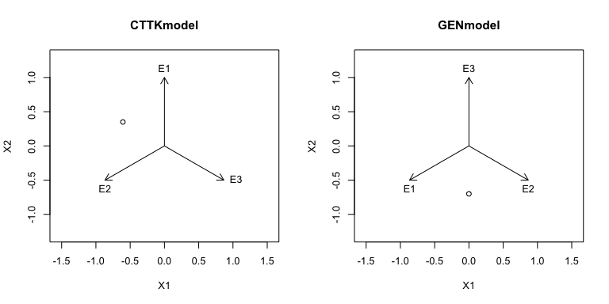

Figure 8. Photoreceptors outputs represented as vectors in a colour space. Each colour vision model uses differently arranged vectors. As long as pairwise angles between vectors are identical, vector arrangements have no biological significance.

Alternatively, users may choose to change some aspect of models. In the example below, a model based on receptor noise is calculated, but with a different photoreceptor input-output transformation:

```r
RNLmodel3<-RNLmodel(model="log",photo=3,R1=R,Rb=Rb,I=D65,C=bee,
                    noise=TRUE,e=c(0.13,0.06,0.11))

ANY.RNLmodel3any<-GENmodel(photo=3, type="length", length=1,R=R,Rb=Rb,I=D65,C=bee, vonKries = TRUE, func=function(x){x/(1+x)}, unity=FALSE,recep.noise=TRUE, noise.given=TRUE,e=c(0.13,0.06,0.11))
```

Note that in this case several parameters differ between models:

`head(RNLmodel3[,c("E1_R1","E2_R1","E3_R1","X1_R1","X2_R1","deltaS")])`

Table 5. `RNLmodel( )` results, showing photoreceptor outputs (Ei_R1), colour locus coordinates (Xi_R1), and the chromaticity distance to the background (deltaS).

|  | E1_R1 | E2_R1 | E3_R1 | X1_R1 | X2_R1 | deltaS |
| --- | --- | --- | --- | --- | --- | --- |
| 500 | 1.1344507 | 1.1953509 | 1.737823 | -0.4156057 | 4.507320 | 4.526440 |
| 510 | 1.0772815 | 1.0148737 | 1.661946 | -1.3869616 | 5.012078 | 5.200441 |
| 520 | 1.0331792 | 0.8486987 | 1.573880 | -2.3102433 | 5.308077 | 5.789034 |
| 530 | 1.0000527 | 0.7021864 | 1.472602 | -3.1266568 | 5.364311 | 6.209011 |
| 540 | 0.9757576 | 0.5786256 | 1.357351 | -3.7942469 | 5.163031 | 6.407277 |
| 550 | 0.9583043 | 0.4788501 | 1.227833 | -4.2926799 | 4.702820 | 6.367387 |

`head(ANY.RNLmodel3any[,c("E1","E2","E3","X1","X2","deltaS")])`

Table 6. `GENmodel( )` based on receptor noise but with a different transformation between photoreceptor input and output. Model results showing photoreceptor outputs (Ei_R1), colour locus coordinates (Xi_R1), and the chromaticity distance to the background (deltaS).

|  | E1 | E2 | E3 | X1 | X2 | deltaS |
| --- | --- | --- | --- | --- | --- | --- |
| 500 | 0.7566593 | 0.7676967 | 0.8504103 | -0.0518106 | 0.6919809 | 0.6939178 |
| 510 | 0.7459792 | 0.7339729 | 0.8404991 | -0.2397641 | 0.8204547 | 0.8547706 |
| 520 | 0.7375318 | 0.7002941 | 0.8283361 | -0.4386927 | 0.9246375 | 1.0234285 |
| 530 | 0.7310689 | 0.6686723 | 0.8134525 | -0.6299436 | 0.9907664 | 1.1740729 |
| 540 | 0.7262656 | 0.6407511 | 0.7953288 | -0.7972665 | 1.0068354 | 1.2842708 |
| 550 | 0.7227822 | 0.6174763 | 0.7734391 | -0.9299592 | 0.9645294 | 1.3398287 |

##Chromaticity distances ($\Delta$S) Chromaticity distances ($\Delta$S) are the Euclidean distances between points in the animal colour space. It is frequently assumed that there is a positive and linear relationship between $\Delta$S values and the probability of discrimination between two colours (although this is not necessarily the case, see Garcia, Spaethe, and Dyer 2017).

In `CTTKmodel`, `EMmodel`, and `GENmodel` model outputs, `deltaS` values represent the distance between the stimulus and the background. In `RNLmodel` output, `deltaS` represents the distance between `R1` and `R2`, or between `R1` and the background when `R1=Rb`.

However, one may want to compute all pairwise chromaticity distance between all stimuli. This is done by the `deltaS` function.

###`deltaS`

`deltaS` function will calculate a matrix with all possible pairwise comparison between stimulus reflectance spectra.

```r
dS<-deltaS(CTTKmodel3)
dS
```

```
##            500        510        520        530        540        550
## 500 0.00000000 0.02343764 0.04687125 0.06846175 0.08687983 0.10187808
## 510 0.02343764 0.00000000 0.02359401 0.04555125 0.06465465 0.08084780
## 520 0.04687125 0.02359401 0.00000000 0.02218159 0.04187766 0.05926490
## 530 0.06846175 0.04555125 0.02218159 0.00000000 0.02009806 0.03855407
## 540 0.08687983 0.06465465 0.04187766 0.02009806 0.00000000 0.01913640
## 550 0.10187808 0.08084780 0.05926490 0.03855407 0.01913640 0.00000000
## 560 0.11458179 0.09549340 0.07595567 0.05719313 0.03927072 0.02087652
## 570 0.12734136 0.11108201 0.09449266 0.07846243 0.06262808 0.04545165
## 580 0.14297463 0.13025419 0.11717462 0.10419581 0.09058492 0.07473277
## 590 0.16350785 0.15451839 0.14492289 0.13478997 0.12316794 0.10850323
## 600 0.18918330 0.18357103 0.17697890 0.16919563 0.15917711 0.14547444
##            560        570        580        590        600
## 500 0.11458179 0.12734136 0.14297463 0.16350785 0.18918330
## 510 0.09549340 0.11108201 0.13025419 0.15451839 0.18357103
## 520 0.07595567 0.09449266 0.11717462 0.14492289 0.17697890
## 530 0.05719313 0.07846243 0.10419581 0.13478997 0.16919563
## 540 0.03927072 0.06262808 0.09058492 0.12316794 0.15917711
## 550 0.02087652 0.04545165 0.07473277 0.10850323 0.14547444
## 560 0.00000000 0.02503866 0.05494735 0.08932603 0.12681114
## 570 0.02503866 0.00000000 0.03011585 0.06475593 0.10248593
## 580 0.05494735 0.03011585 0.00000000 0.03472163 0.07255244
## 590 0.08932603 0.06475593 0.03472163 0.00000000 0.03786149
## 600 0.12681114 0.10248593 0.07255244 0.03786149 0.00000000
```

It may be useful to visualise `deltaS` output graphically using the ‘corrplot’ package:

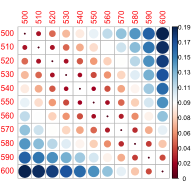

Figure 9. Graphical representation of chromaticity distances using `corrplot` package. Size and colour of circles denote chromaticity distances between each reflectance spectra.

```r
library(corrplot)
corrplot(corr=dS, is.corr=FALSE)
```

##Plotting models

Models outputs can be easily plotted using the `plot` function, for dichromatic and trichromatic animals, or `plot3d.colourvision` (requires package `rgl`) for tetrachromatic animals. In addition, `radarplot` plots `Qr` and `E` values into a radar plot. For threshold data, `plot(model)` plots sensitivity values (ln-transformed) per wavelength.

###`plot(model)` For dichromatic and trichromatic animals. Plots model specific chromaticity diagrams. For instance:

Chittka and Menzel (1992) Hexagon for trichromatic animals:

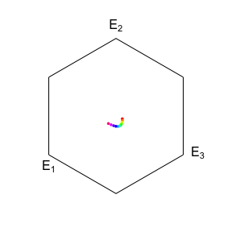

Figure 10. Chittka and Menzel (1992) colour hexagon representing the colour space boundaries of a thrichroamtic animal (*Apis mellifera*). Circles denotes colour locus of simulated reflectance spectra (Figure 7).

```r
par(mar=c(1,1,1,1))
colours<-rainbow(n=(ncol(R)-1))
plot(CTTKmodel3, cex=0.5, col=colours)
```

Endler and Mielke (2005) adapted to trichromatic animals:

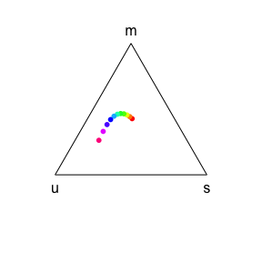

Figure 11. Endler and Mielke (2005) colour triangle representing the colour space boundaries of a trichromatic animal (*Apis mellifera*). Circles denotes colour locus of simulated reflectance spectra (Figure 7).

```r
par(mar=c(1,1,1,1))
plot(EMmodel3, cex=0.8, col=colours)
```

Colour spaces of receptor noise limited models (Vorobyev and Osorio 1998; Vorobyev et al. 1998) do not have boundaries. Therefore, it is useful to plot results alongside vectors representing $E$-values:

```r
par(mar=c(5, 4, 4, 2) + 0.1)
```

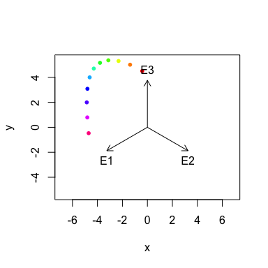

Figure 12. Receptor Noise Limited Model colour space of a trichromatic animal (*Apis mellifera*). Circles denote colour locus of simulated reflectance spectra (Figure 7). Vectors represent photoreceptor outputs.

```r
plot(RNLmodel3, cex=0.8, pch=16, col=colours)
```

###`plot(model)` for threshold values Colour thresholds based on receptor noise limited models (Vorobyev and Osorio 1998):

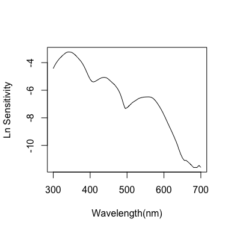

Figure 13. Threshold spectral sensitivity of a trichromatic animal (*Apis mellifera*) based on receptor noise (`RNLthres( )` function).

```r
plot(thres)
```

###`plot3d.colourvision(model)`

For tetrachromatic animals, `plot3d.colourvision` plots model specific 3D colour spaces. Chittka (1992) model is represented by a hexagonal trapezohedron:

```r
library(rgl)
CTTKmodel4<-CTTKmodel(R=R, I=D65, C=photor(c(350,420,490,560),beta.band=FALSE), Rb=Rb)
```

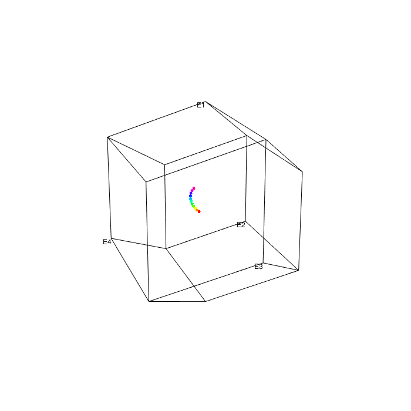

Figure 14. Chittka (1992) hexagonal trapezohedron representing the colour space boundaries of a tetrachromatic animal. Circles denotes colour locus of simulated reflectance spectra (Figure 7).

```r
library(rgl)
plot3d.colourvision(CTTKmodel4, s.col = colours, size=4)
```

```r
EMmodel4<-EMmodel(R=R, I=D65, C=photor(c(350,420,490,560),beta.band=FALSE), Rb=Rb)
```

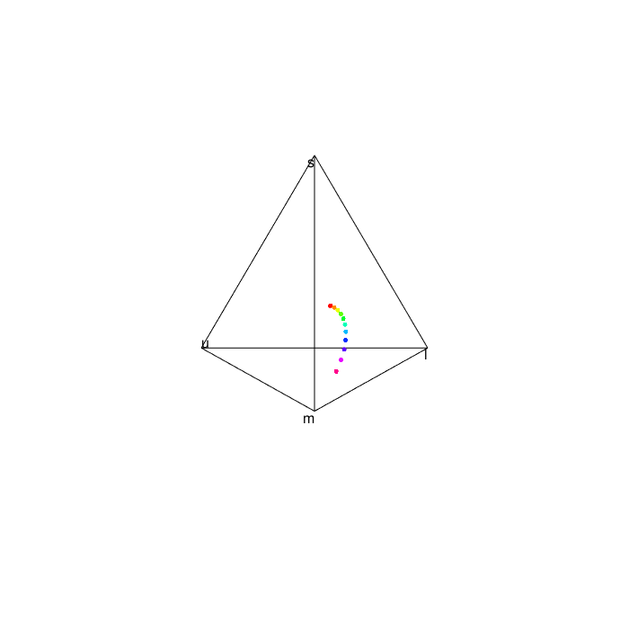

Figure 15. Endler and Mielke (2005) tetrahedron representing the colour space boundaries of a tetrachromatic animal. Circles denotes colour locus of simulated reflectance spectra (Figure 7).

```r
plot3d.colourvision(EMmodel4, s.col = colours, size=4)
```

```r
RNLmodel4<-RNLmodel(model="log", R1=R, I=D65, C=photor(c(350,420,490,560),beta.band=FALSE), Rb=Rb, noise=TRUE, e=c(0.1,0.07,0.07,0.05))
```

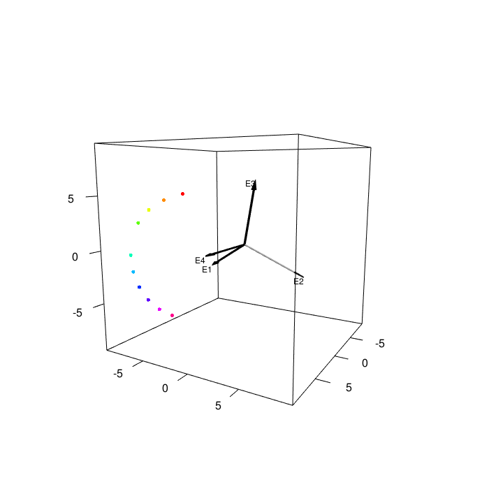

Figure 16. Receptor Noise Limited Model colour space of a tetrachromatic animal. Circles denote colour locus of simulated reflectance spectra (Figure 7). Vectors represent photoreceptor outputs.

```r
plot3d.colourvision(RNLmodel4, xlab="", ylab="", zlab="", col = colours, size=4)
```

###`radarplot(model)` `radarplot` plots quantum catches or $E$-values into a radar plot.

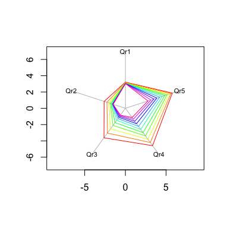

Figure 17. Radar plot representing `CTTKmodel( )` photoreceptor inputs of a pentachromatic animal. Each polygon denotes a reflectance spectrum in Figure 7.

```r
CTTKmodel5<-CTTKmodel(R=R, I=D65, C=photor(c(350,410,470,530,590),beta.band=FALSE), Rb=Rb)
radarplot(CTTKmodel5, item="Qr", item.labels=TRUE, border=colours)
```

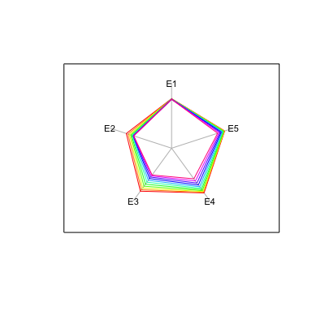

Figure 18. Radar plot representing `CTTKmodel( )` photoreceptor outputs of a pentachromatic animal. Each polygon denotes a reflectance spectrum in Figure 7.

```r
radarplot(CTTKmodel5, item="E", item.labels=TRUE, ann=FALSE, xaxt = "n", yaxt = "n", ylim=c(-1.2,1.2), xlim=c(-1.2,1.2), border=colours)
```

#References

Chittka, Lars. 1992. “The colour hexagon: a chromaticity diagram based on photoreceptor excitations as a generalized representation of colour opponency.” *J Comp Physiol A* 170: 533–43.

Chittka, Lars, and R Menzel. 1992. “The evolutionary adaptation of flower colours and the insect pollinators’ colour vision.” *J Comp Physiol A* 171 (2): 171–81.

Endler, John A. 1990. “On the measurement and classification of colour in studies of animal colour patterns.” *Biol J Linn Soc* 41 (4): 315–52.

Endler, John A, and P Mielke. 2005. “Comparing entire colour patterns as birds see them.” *Biol J Linn Soc* 86: 405–31.

Garcia, Jair E, Johannes Spaethe, and Adrian G Dyer. 2017. “The path to colour discrimination is S-shaped: behaviour determines the interpretation of colour models.” *J Comp Physiol A*, September.

Gawryszewski, Felipe M. 2018. “Colour vision models: Some simulations, a general n-dimensional model, and the colourvision R package.” *Ecology and Evolution*. https://doi.org/10.1002/ece3.4288.

Gawryszewski, Felipe M, and P C Motta. 2012. “Colouration of the orb-web spider Gasteracantha cancriformis does not increase its foraging success.” *Ethol Ecol Evol* 24 (1): 23–38.

Govardovskii, V I, N Fyhrquist, T Reuter, D G Kuzmin, and K Donner. 2000. “In search of the visual pigment template.” *Vis. Neurosci.* 17 (4): 509–28.

Hempel de Ibarra, N, M Giurfa, and Misha Vorobyev. 2001. “Detection of coloured patterns by honeybees through chromatic and achromatic cues.” *J Comp Physiol A* 187 (3): 215–24.

Kelber, Almut, Misha Vorobyev, and Daniel Osorio. 2003. “Animal colour vision–behavioural tests and physiological concepts.” *Biol Rev Camb Philos Soc* 78 (1): 81–118.

Kemp, Darrell J, Marie E Herberstein, Leo J Fleishman, John A Endler, Andrew T D Bennett, Adrian G Dyer, Nathan S Hart, Justin Marshall, and Martin J Whiting. 2015. “An integrative framework for the appraisal of coloration in nature.” *Am Nat* 185 (6): 705–24.

Osorio, Daniel, and Misha Vorobyev. 2008. “A review of the evolution of animal colour vision and visual communication signals.” *Vision Res* 48 (20): 2042–51.

Peitsch, D, A Fietz, H Hertel, JM de Souza, Dora F Ventura, and R Menzel. 1992. “The spectral input systems of hymenopteran insects and their receptor-based color-vision.” *J Comp Physiol A* 170 (1): 23–40.

Pike, T W. 2012. “Generalised chromaticity diagrams for animals with n-chromatic colour vision.” *Journal of Insect Behavior* 255: 277–86.

Renoult, Julien P, Almut Kelber, and H Martin Schaefer. 2017. “Colour spaces in ecology and evolutionary biology.” *Biol Rev Camb Philos Soc* 92 (1): 292–315.

Thery, Marc, and J Casas. 2002. “Predator and prey views of spider camouflage.” *Nature* 415 (6868): 133–33.

Vorobyev, Misha, and D Osorio. 1998. “Receptor noise as a determinant of colour thresholds.” *Proceedings of the Royal Society B: Biological Sciences* 265 (1394): 351–58.

Vorobyev, Misha, D Osorio, Andrew T D Bennett, N Justin Marshall, and Innes C Cuthill. 1998. “Tetrachromacy, oil droplets and bird plumage colours.” *J Comp Physiol A* 183 (5): 621–33.